# Practical 8 Key - Case-control imbalance in GWAS

Before you begin:

- Make sure that R is installed on your computer
- For this lab, we will use the following R libraries:

```r
library(data.table)
library(dplyr)
library(qqman)
library(ggplot2)
```

## Introduction

We will generate a simulated dataset consisting of 3 binary traits with different amounts of case-control imbalance, and a genetic data set of **null** SNPs to examine the distribution of the test statistics when scanning for associations.

## Data preparation

We first need to define the path to the PLINK 1.9 and REGENIE binaries.

```r
plink_binary <- "/SISGM19/bin/plink1.9"
regenie_binary <- "/SISGM19/bin/regenie"
```

If you don’t have REGENIE installed on your machine, download the R implementation [here](https://gatech.box.com/s/uyk4tybghy9ricp4zfw7r7fj63ursuh5) and change the path of the variable `regenie_script` to the path of the script on your machine.

```r
regenie_script <- "/SISGM19/data/run_regenie.r"
source(regenie_script)
```

## Simulate the data

We use PLINK1.9 to simulate the genetic dataset. For $N=10,000$ samples, let’s simulate 10,000 variants where 5,000 are common with MAF chosen from a Uniform(0.05, 0.5) distribution and for the rare variants, we will use a Uniform(0.001, 0.01) distribution. Run the following command in R to get the simulated data:

```r
N <- 10e3
# Generate a configuration file specifying allele frequencies (a,b) for Uniform(a,b) distribution
write(paste0("5000 common 0.05 0.5 1 1"), "sim.config")
write(paste0("5000 rare 0.001 0.01 1 1"), "sim.config", append = TRUE)
# Run PLINK1.9
cmd <- sprintf("%s --make-bed --simulate sim.config --simulate-ncases %d --simulate-ncontrols 0 --simulate-prevalence 0.1  --out cc_imb_geno", plink_binary, N)
system(cmd)
```

You should now have files `cc_imb_geno.{bed,bim,fam}`.

For the phenotype data simulation, we will simulate 3 phenotypes with different levels of case-control imbalance (case-control ratios [CCR] 1:9, 1:99, and 1:199). Run the following code

```r
# get FID/IID from FAM file
sample.ids <- fread("cc_imb_geno.fam", header = FALSE)
N <- nrow(sample.ids)

## Set prevalence = 10% (CCR 1:9)
y1 <- rbinom(N, 1, prob = 0.1 )
## Set prevalence = 1% (CCR 1:99)
y2 <- rbinom(N, 1, prob = 0.01 )
## Set prevalence = 0.5% (CCR 1:199)
y3 <- rbinom(N, 1, prob = 0.005 )

# write to file
fwrite(
  data.frame(FID = sample.ids$V1, IID = sample.ids$V2, Y1 = y1, Y2 = y2, Y3 = y3),
  "cc_imb_pheno.txt",
  sep = "\t", na = NA, quote = FALSE
)
```

You should now have a file named `cc_imb_pheno.txt`.

## Exercises

We will now assess the null distribution of our test statistics when performing association testing using different models.

### 1. Run the GWAS in REGENIE for the 3 traits

```r
cmd <- sprintf('%s --bed cc_imb_geno --phenoFile cc_imb_pheno.txt --bt --step 2 --bsize 2000 --ignore-pred --out test_regenie', regenie_binary)
system(cmd)
```

This will produce three sumstats files (one for each phenotype) which you can read in R:

```r
sumstats.y1 <- fread("test_regenie_Y1.regenie")
sumstats.y2 <- fread("test_regenie_Y2.regenie")
sumstats.y3 <- fread("test_regenie_Y3.regenie")
```

**To run the R implementation instead**, run the following for each trait (this computes the association tests and stores it in the R variable directly)

```r
sumstats.y1 <- run_regenie_step2_bt(
  bedfile = "cc_imb_geno",
  phenofile = "cc_imb_pheno.txt",
  phenocol = "Y1",
  bsize = 300
)
sumstats.y2 <- run_regenie_step2_bt(
  bedfile = "cc_imb_geno",
  phenofile = "cc_imb_pheno.txt",
  phenocol = "Y2",
  bsize = 300
)
sumstats.y3 <- run_regenie_step2_bt(
  bedfile = "cc_imb_geno",
  phenofile = "cc_imb_pheno.txt",
  phenocol = "Y3",
  bsize = 300
)
```

### 2. Make a QQ plot of the p-values for each phenotype

Since these are null SNPs, how does it compare to what we expect?

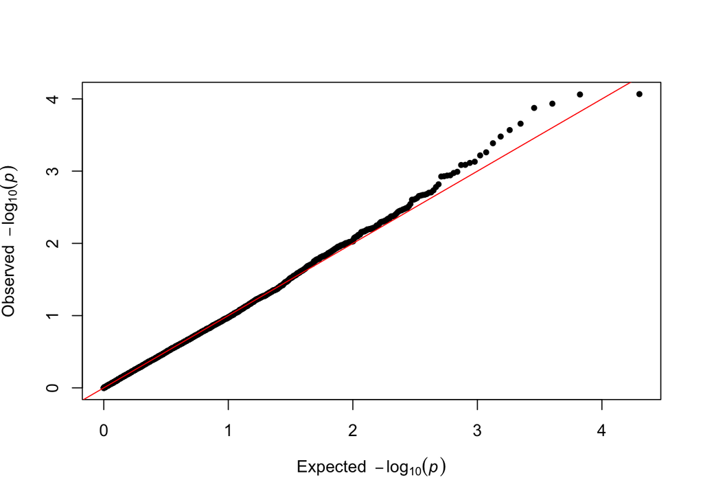

```r
qq(10^-sumstats.y1$LOG10P)
```

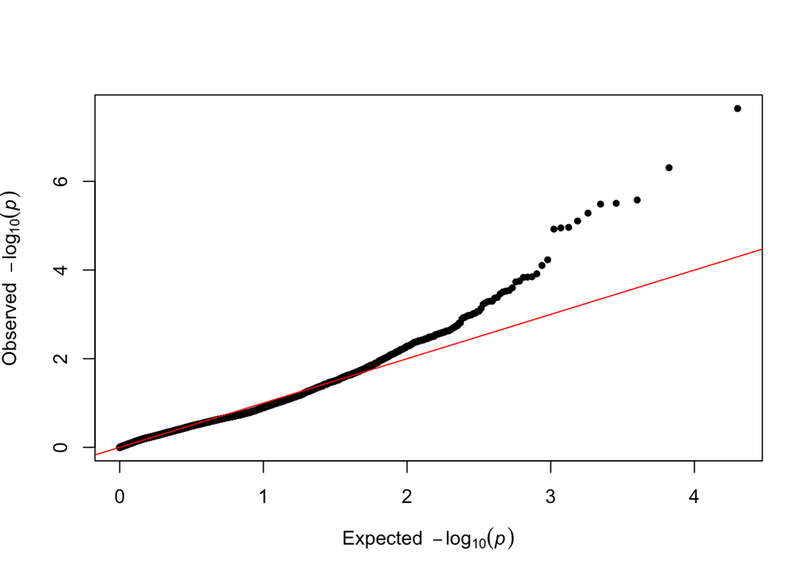

```r
qq(10^-sumstats.y2$LOG10P)
```

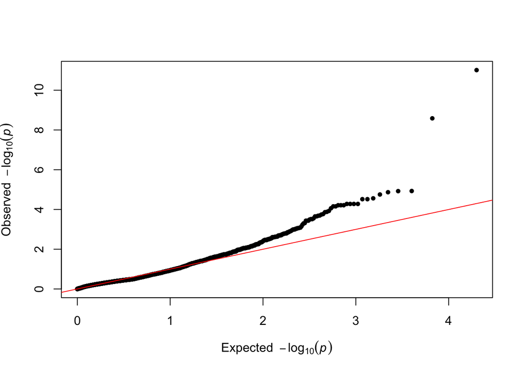

```r
qq(10^-sumstats.y3$LOG10P)
```

**Observation**: As case-control imbalance becomes more severe (Y1 with 1:9, Y2 with 1:99, Y3 with 1:199), the QQ plots deviate more from the diagonal, especially in the right tail. This indicates inflation of test statistics for rare variants as the imbalance worsens. Y1 (least imbalanced) should show QQ plot closest to the diagonal for null SNPs, while Y3 (most imbalanced) will show the most deviation.

### 3. Make a histogram of the test statistics for each phenotype

Make a histogram of the test statistics for each phenotype and overlay with a normal distribution. How well do they match?

```r
plot.sumstats.hist <- function(df, title = ""){
  df$Z_STAT <- sign(df$BETA) * sqrt(df$CHISQ)
  ggplot(df,  aes(x = Z_STAT) ) +
  geom_histogram(aes(y = after_stat(density)), colour="black", fill="white", bins = 100) +
  stat_function(
    fun = dnorm,
    col = "red",
    args = list(
      mean = mean(df$Z_STAT, na.rm = TRUE),
      sd = sd(df$Z_STAT, na.rm = TRUE)
      )
  ) +
    theme_bw(16) +
    labs(title = title)
}
```

Now make histogram plot for each trait.

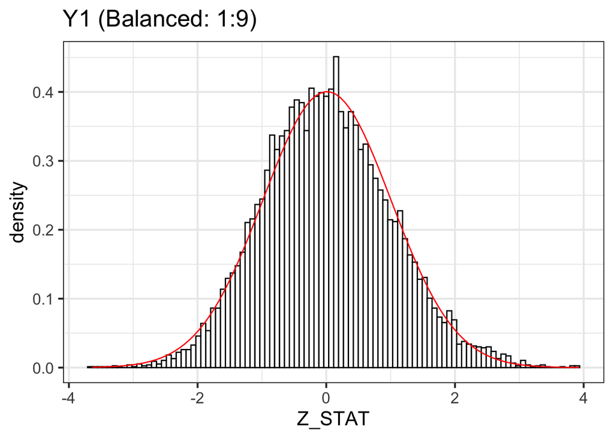

```r
# for Y1
plot.sumstats.hist(sumstats.y1, title = "Y1 (Balanced: 1:9)")
```

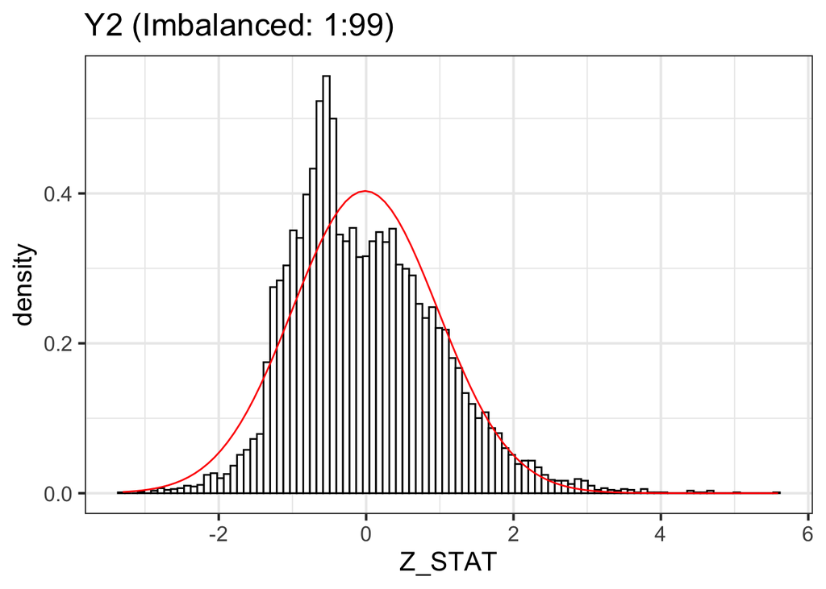

```r
# for Y2
plot.sumstats.hist(sumstats.y2, title = "Y2 (Imbalanced: 1:99)")
```

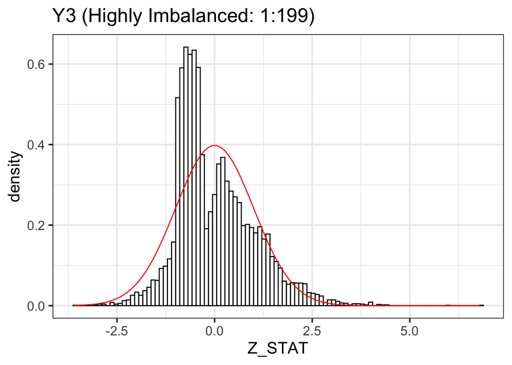

```r
# for Y3
plot.sumstats.hist(sumstats.y3, title = "Y3 (Highly Imbalanced: 1:199)")
```

The worse the imbalance, the more the empirical distribution departs from the expected null distribution, which affects our interpretation of p-values.

### 4. Separate the histogram for common and rare SNPs

Re-do Question 3 but now separate the histogram for common and rare SNPs. We define a new function to generate the histogram for each class of variants.

```r
plot.sumstats.hist.by.group <- function(df, title = ""){
  df$Z_STAT <- sign(df$BETA) * sqrt(df$CHISQ)
  df$group <- ifelse(grepl("rare", df$ID), "Rare SNPs", "Common SNPs")
  # Step 2: Generate normal density data for each group
  moment.ests <- with(df, tapply(Z_STAT, group, function(x) c(mean=mean(x, na.rm = TRUE), sd=sd(x, na.rm = TRUE))))
  z_stat_seq <- seq(min(df$Z_STAT, na.rm = TRUE), max(df$Z_STAT, na.rm = TRUE), length.out = 100)
  normal_curve_data <- do.call(rbind, lapply(unique(df$group), function(grp) {
    mean <- moment.ests[[grp]]['mean']; sd <- moment.ests[[grp]]['sd']
    density <- dnorm(z_stat_seq, mean = mean, sd = sd)
    data.frame(Z_STAT = z_stat_seq, density = density, group = grp)
  }))

  ggplot(df,  aes(x = Z_STAT) ) +
  geom_histogram(aes(y = ..density..), colour="black", fill="white", bins = 100) +
  geom_line(data = normal_curve_data, aes(x = Z_STAT, y = density), col = "red", size = 1) +
  facet_wrap(~group) +
  theme_bw(16) +
  labs(title = title)
}
```

Make a histogram of the test statistics distribution at common/rare SNPs for each trait.

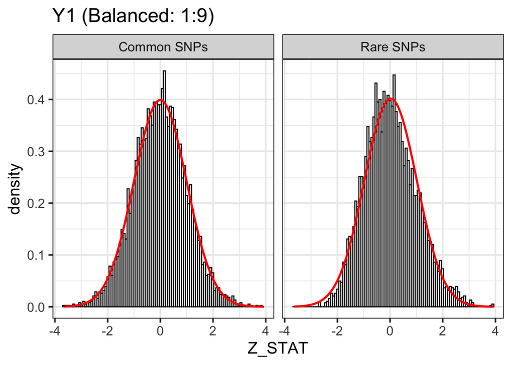

```r
# for Y1
plot.sumstats.hist.by.group(sumstats.y1, "Y1 (Balanced: 1:9)")
```

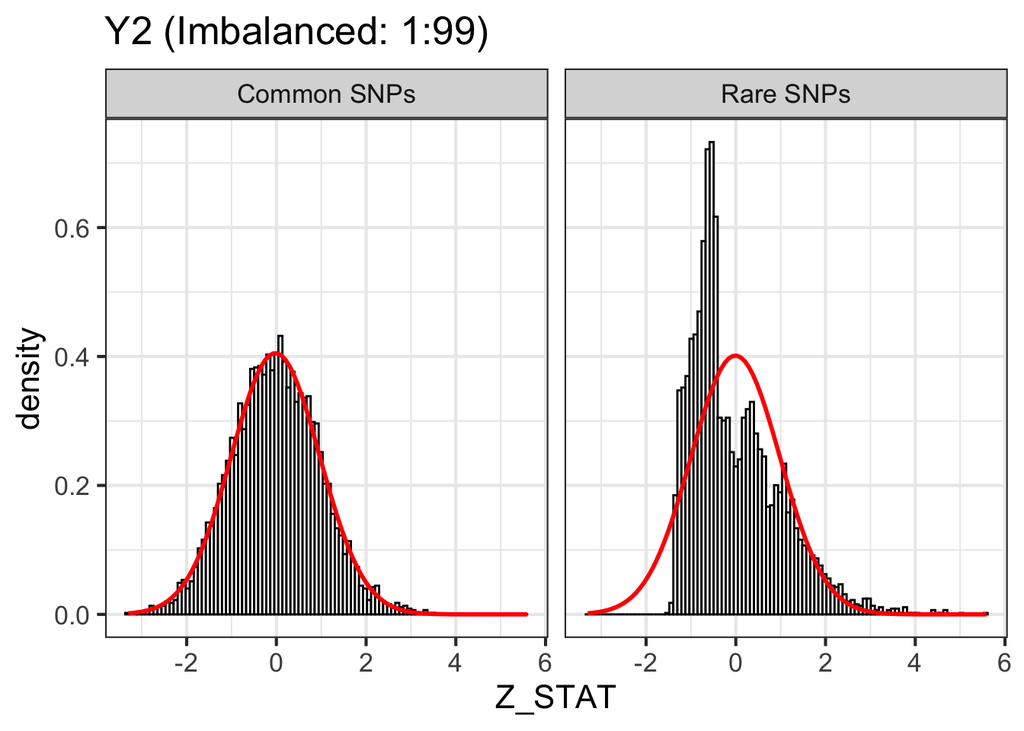

```r
# for Y2
plot.sumstats.hist.by.group(sumstats.y2, "Y2 (Imbalanced: 1:99)")
```

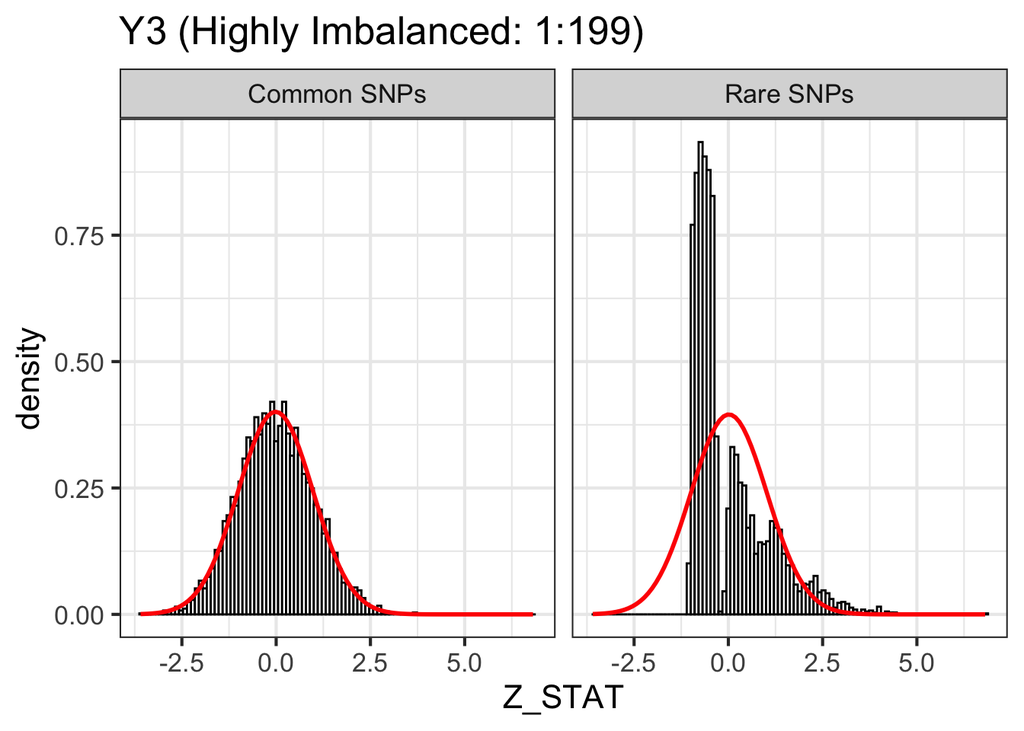

```r
# for Y3
plot.sumstats.hist.by.group(sumstats.y3, "Y3 (Highly Imbalanced: 1:199)")
```

This demonstrates why rare variants are particularly vulnerable to case-control imbalance artifacts: with fewer cases, rare variant associations can produce inflated test statistics under the null when there is case-control imbalance.

### 5. Re-run GWAS with Firth correction (Extra)

Re-run GWAS but now applying Firth correction to address case-control imbalance. Make a QQ plot of the -log10 p-values and examine the histograms of the test statistic.

```r
cmd <- sprintf('%s --bed cc_imb_geno --phenoFile cc_imb_pheno.txt --bt --step 2 --bsize 2000 --firth --approx --ignore-pred --out test_regenie_wFirth', regenie_binary)
system(cmd)
```

This will produce three files (one for each phenotype) which you can read in R:

```r
sumstats.y1.firth <- fread("test_regenie_wFirth_Y1.regenie")
sumstats.y2.firth <- fread("test_regenie_wFirth_Y2.regenie")
sumstats.y3.firth <- fread("test_regenie_wFirth_Y3.regenie")
```

**To run the R implementation instead**:

```r
sumstats.y1.firth <- run_regenie_step2_bt(
  bedfile = "cc_imb_geno",
  phenofile = "cc_imb_pheno.txt",
  phenocol = "Y1",
  bsize = 300,
  firth = TRUE
)
sumstats.y2.firth <- run_regenie_step2_bt(
  bedfile = "cc_imb_geno",
  phenofile = "cc_imb_pheno.txt",
  phenocol = "Y2",
  bsize = 300,
  firth = TRUE
)
sumstats.y3.firth <- run_regenie_step2_bt(
  bedfile = "cc_imb_geno",
  phenofile = "cc_imb_pheno.txt",
  phenocol = "Y3",
  bsize = 300,
  firth = TRUE
)
```

**Looking at the test statistics and p-values with Firth correction**:

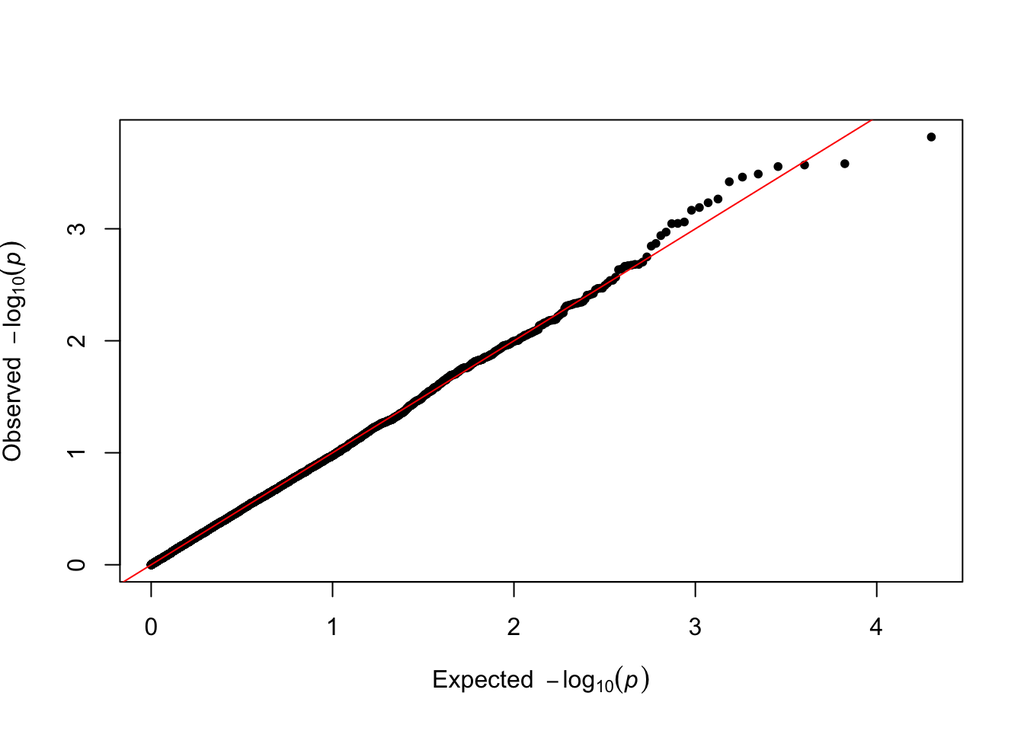

```r
qq(10^-sumstats.y1.firth$LOG10P)
```

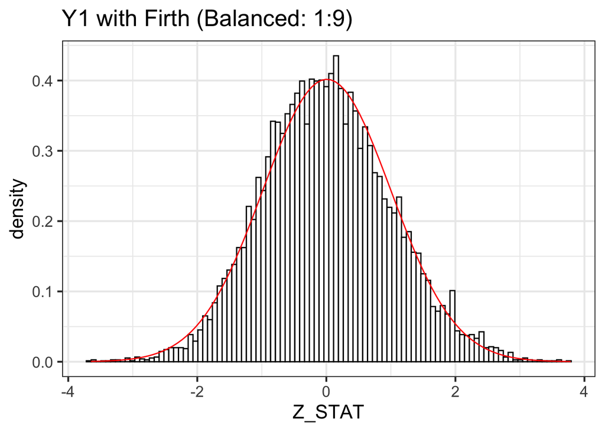

```r
plot.sumstats.hist(sumstats.y1.firth, title = "Y1 with Firth (Balanced: 1:9)")
```

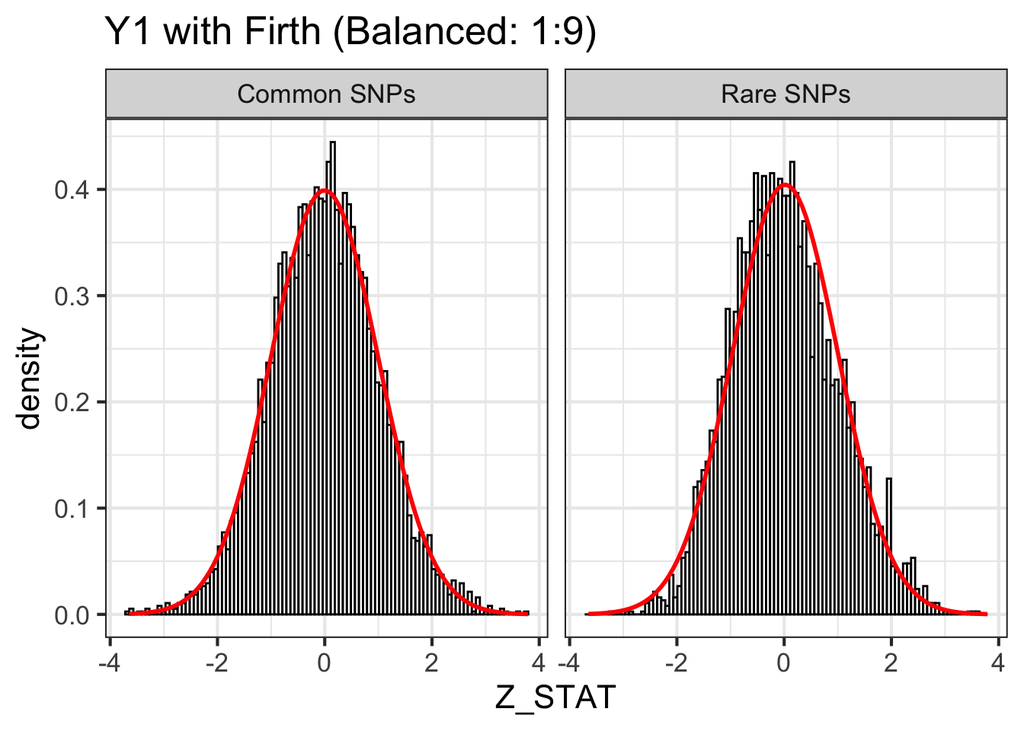

```r
plot.sumstats.hist.by.group(sumstats.y1.firth, "Y1 with Firth (Balanced: 1:9)")
```

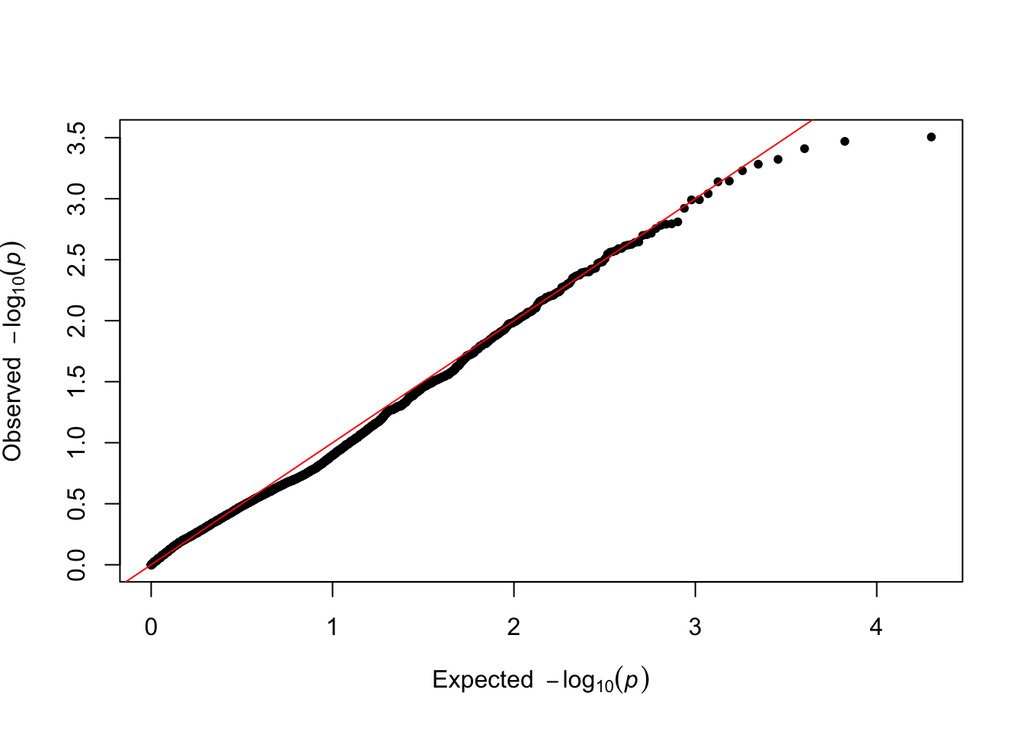

```r
qq(10^-sumstats.y2.firth$LOG10P)
```

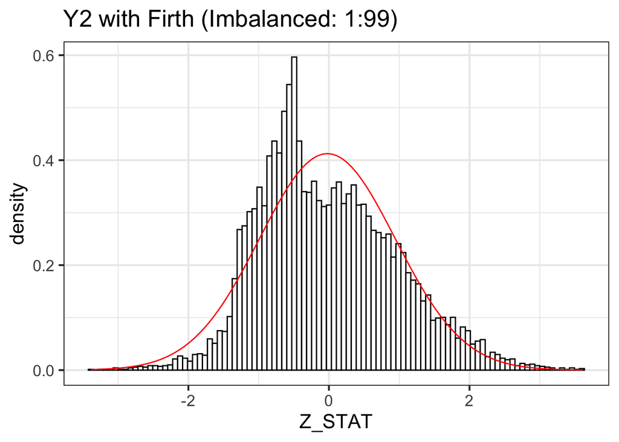

```r
plot.sumstats.hist(sumstats.y2.firth, title = "Y2 with Firth (Imbalanced: 1:99)")
```

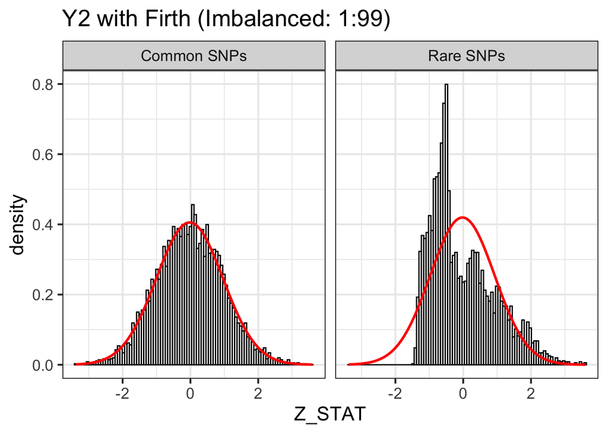

```r
plot.sumstats.hist.by.group(sumstats.y2.firth, "Y2 with Firth (Imbalanced: 1:99)")
```

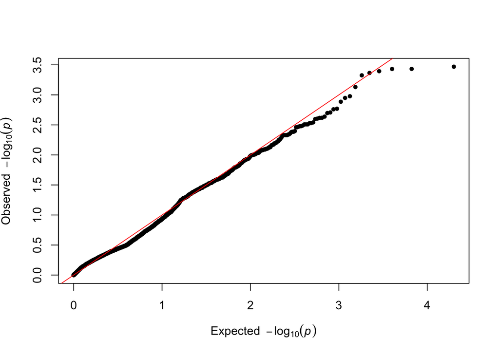

```r
qq(10^-sumstats.y3.firth$LOG10P)
```

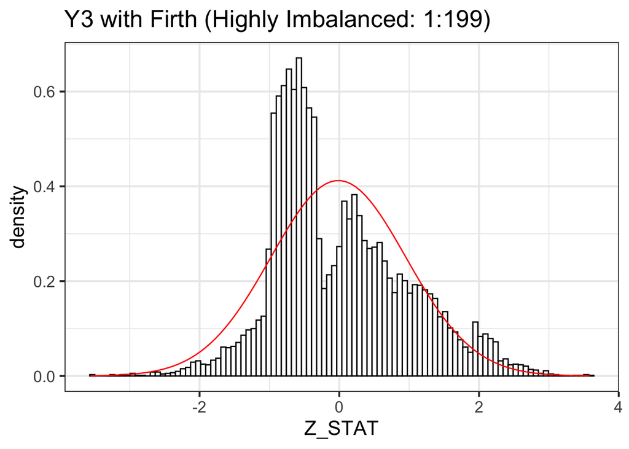

```r
plot.sumstats.hist(sumstats.y3.firth, title = "Y3 with Firth (Highly Imbalanced: 1:199)")
```

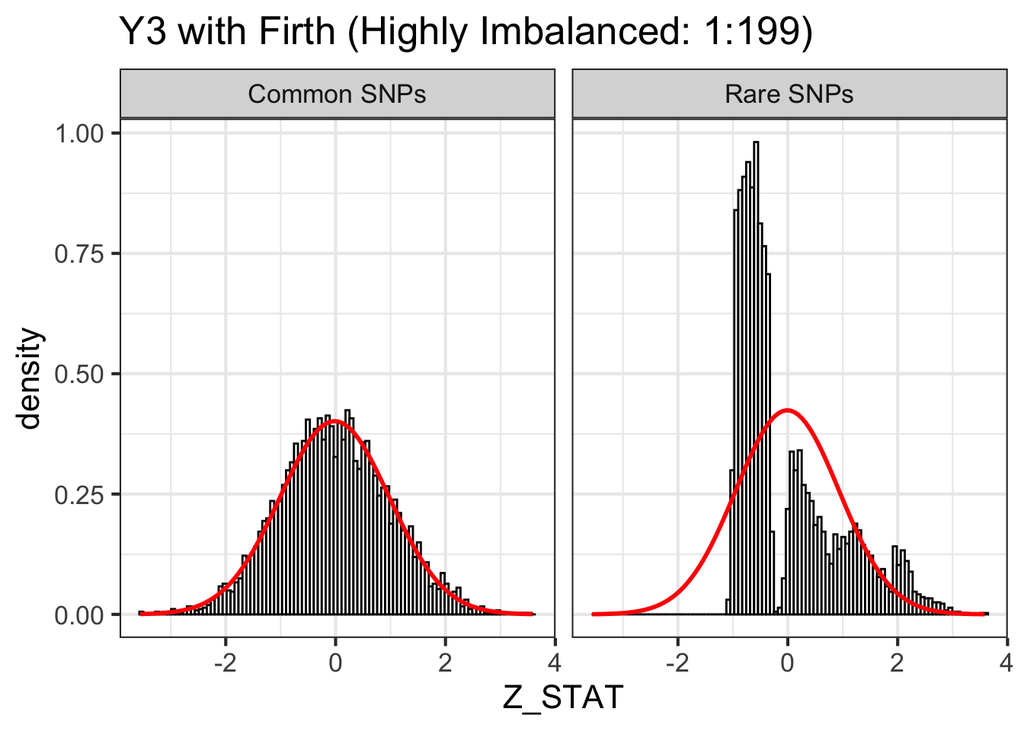

```r
plot.sumstats.hist.by.group(sumstats.y3.firth, "Y3 with Firth (Highly Imbalanced: 1:199)")
```